# Moth Eggs Test

Last Updated: October 02, 2024 08:28:04

Moth Eggs Researchers were interested in looking for an association between body size (BodyMass after taking the log of the measurement in grams) and the number of eggs produced by a moth. BodyMass and the number of eggs present for 39 moths are in the file MothEggs.

### 1. Before looking at the data, would you expect the association between body mass and number of eggs to be positive or negative? Explain.

I would expect the association between body mass and number of eggs to be positive. This is because larger moths have more body mass and would be able to produce more eggs.

### 2. What is the value of the correlation coefficient for measuring the strength of linear association between BodyMass and Eggs?

```r
cor(BodyMass, Eggs)
```

```
## [1] 0.4413396
```

#### 2.1 Is the association between these two variables statistically significant? Justify your answer.

Since the r-value is 0.4413396, which is not close to 0, the association between BodyMass and Eggs is statistically significant. The distribution is a weak but positive linear relationship.

### 3. Fit a linear regression model for predicting Eggs from BodyMass.

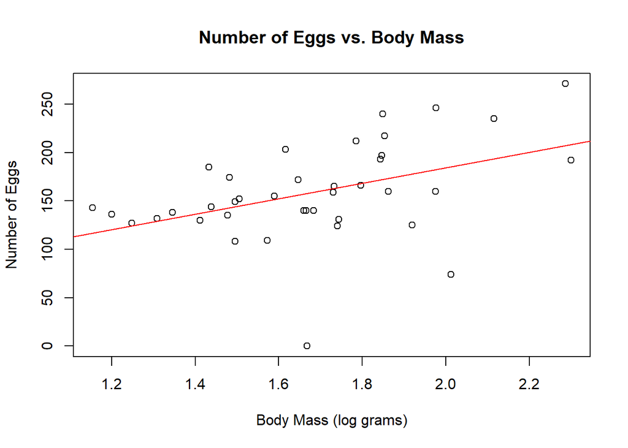

```r
modelWithOutlier <- lm(Eggs ~ BodyMass)
plot(Eggs ~ BodyMass, xlab = "Body Mass (log grams)", ylab = "Number of Eggs", main = "Number of Eggs vs. Body Mass")
abline(modelWithOutlier, col = "red")
```

```r
summary(modelWithOutlier)
```

```
##
## Call:
## lm(formula = Eggs ~ BodyMass)
##
## Residuals:
##      Min       1Q   Median       3Q      Max
## -157.586  -17.187    3.162   25.790   67.960
##
## Coefficients:
##             Estimate Std. Error t value Pr(>|t|)
## (Intercept)    24.38      45.38   0.537  0.59423
## BodyMass       79.86      26.69   2.992  0.00492 **
## ---
## Signif. codes:  0 '***' 0.001 '**' 0.01 '*' 0.05 '.' 0.1 ' ' 1
##
## Residual standard error: 44.75 on 37 degrees of freedom
## Multiple R-squared:  0.1948, Adjusted R-squared:  0.173
## F-statistic:  8.95 on 1 and 37 DF,  p-value: 0.004916
```

#### 3.1 What is the equation of the least squares regression line?

`Eggs = 79.86(BodyMass) + 24.38`

### 4. The conditions for inference are not met, primarily because there is one very unusual observation.

#### 4.1 Identify this observation

```r
outlier <- which.max(modelWithOutlier$residuals)
eggs[outlier, ]
```

```
##    BodyMass Eggs
## 15    1.849  240
```

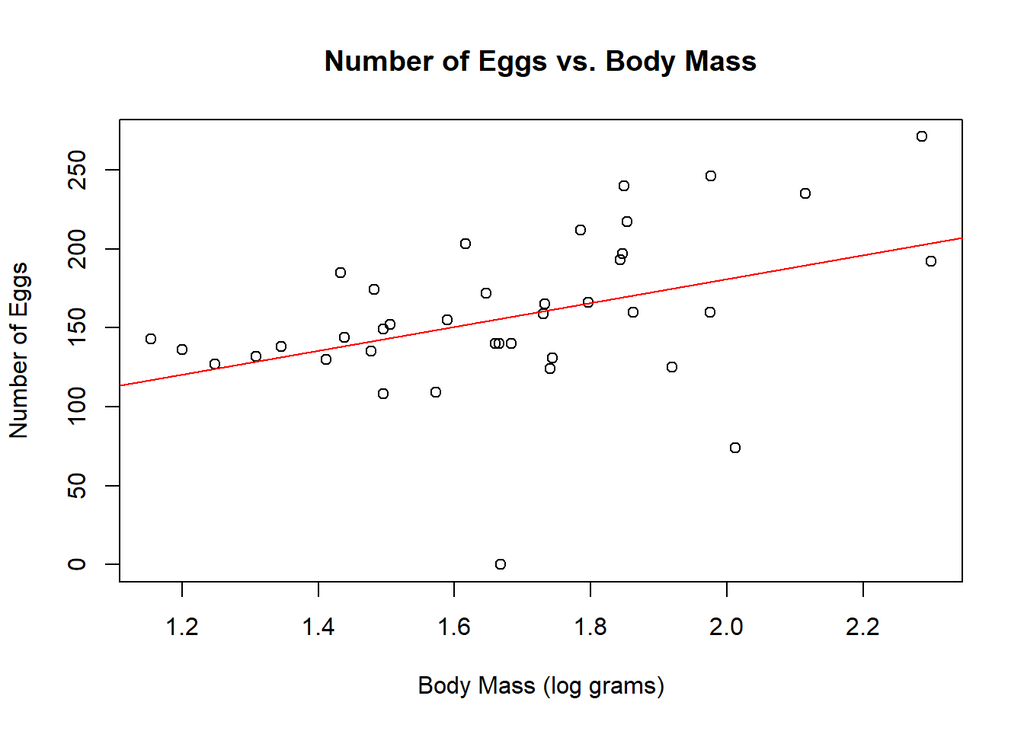

```r
eggs <- eggs[-outlier, ]
modelWithoutOutlier <- lm(Eggs ~ BodyMass, data = eggs)
plot(Eggs ~ BodyMass, xlab = "Body Mass (log grams)", ylab = "Number of Eggs", main = "Number of Eggs vs. Body Mass")
abline(modelWithoutOutlier, col = "red")
```

```r
summary(modelWithoutOutlier)
```

```
##
## Call:
## lm(formula = Eggs ~ BodyMass, data = eggs)
##
## Residuals:
##      Min       1Q   Median       3Q      Max
## -155.824  -15.559    3.825   25.507   68.389
##
## Coefficients:
##             Estimate Std. Error t value Pr(>|t|)
## (Intercept)    29.75      44.62   0.667  0.50922
## BodyMass       75.58      26.31   2.873  0.00678 **
## ---
## Signif. codes:  0 '***' 0.001 '**' 0.01 '*' 0.05 '.' 0.1 ' ' 1
##
## Residual standard error: 43.88 on 36 degrees of freedom
## Multiple R-squared:  0.1865, Adjusted R-squared:  0.1639
## F-statistic: 8.252 on 1 and 36 DF,  p-value: 0.006784
```

#### 4.3 What is the equation of the least squares regression line?

`Eggs = 75.58(BodyMass) + 29.75`

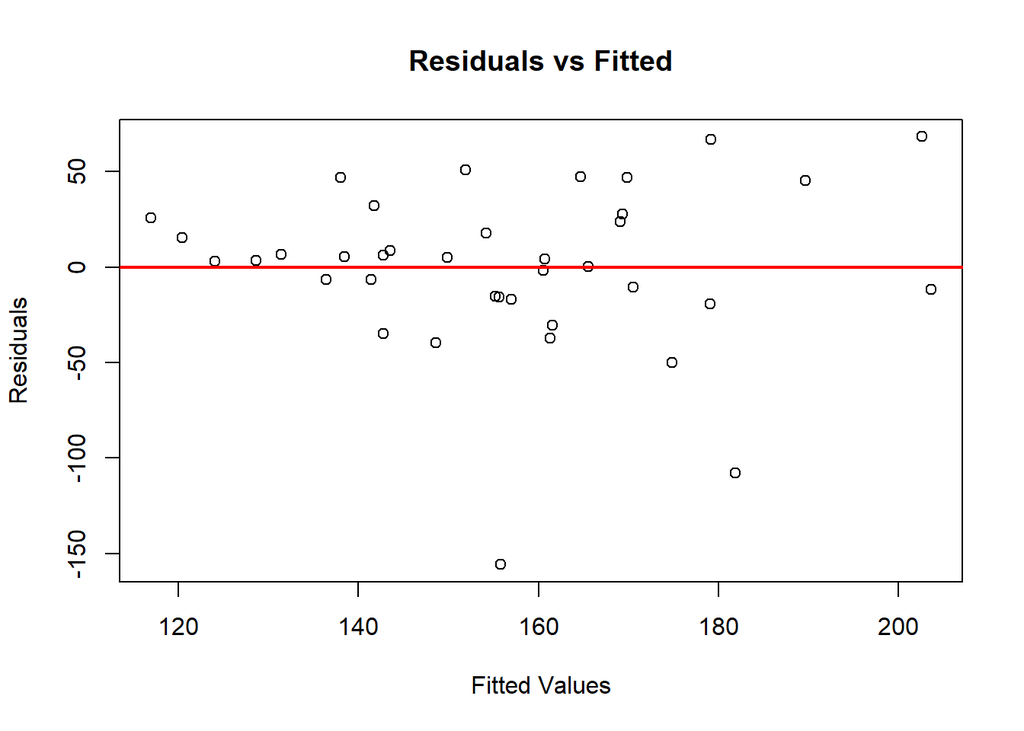

```r
plot(modelWithoutOutlier$fitted.values, modelWithoutOutlier$residuals, main = "Residuals vs Fitted", xlab = "Fitted Values", ylab = "Residuals")
abline(h = 0, col = "red", lwd = 2)
```

### 7. Compare the percent of variability in the number of eggs that is explained with and without the moth that had no eggs.

```r
summary(modelWithOutlier)$r.squared
```

```
## [1] 0.1947807
```

```r
summary(modelWithoutOutlier)$r.squared
```

```
## [1] 0.1864828
```